# European Soccer Database Investigation Project

All other numerical attributes can be analyzed the same way. **Please, feel free to change the attribute value in the next cell, then run it.**

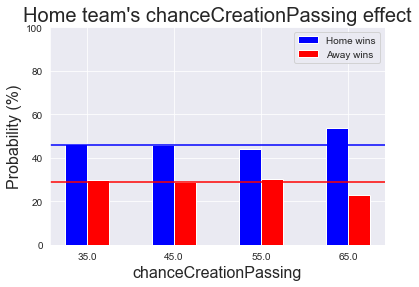

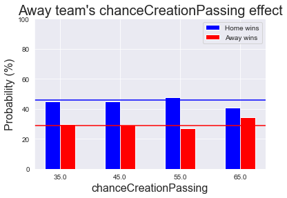

```python
# Change the value of this variable with appropriate attribute name then run the cell
attribute = 'chanceCreationPassing'
df = team_attribute_numeric(attribute)
if not df.empty:
    # Generate home graph
    original = df['home_team_{}'.format(attribute)].values
    home = df.groupby(['match_result']).get_group('home_win')['home_team_{}'.format(attribute)].values
    away = df.groupby(['match_result']).get_group('away_win')['home_team_{}'.format(attribute)].values
    posterior_probabilities(original ,home, away, bins=4, hist_range=(30,70))
    plt.title('Home team\'s {} effect'.format(attribute), fontsize=20)
    plt.xlabel(attribute, fontsize=16)
    plt.ylabel('Probability (%)', fontsize=16)
    # Generate away graph
    original = df['away_team_{}'.format(attribute)].values
    home = df.groupby(['match_result']).get_group('home_win')['away_team_{}'.format(attribute)].values
    away = df.groupby(['match_result']).get_group('away_win')['away_team_{}'.format(attribute)].values
    posterior_probabilities(original ,home, away, bins=4, hist_range=(30,70))
    plt.title('Away team\'s {} effect'.format(attribute), fontsize=20)
    plt.xlabel(attribute, fontsize=16)
    plt.ylabel('Probability (%)', fontsize=16);
```

The following function is to do the same analysis on attributes with string values.

```python
def team_attribute_str(attribute='buildUpPlaySpeedClass'):
    '''
    Argument: attribute as string (it should be one of the team's attribute with string values)
    Usage: adds the values of this attribute to the new dataframe then gives two graphs to show the effect of this
    attribute on match result
    Output: Two graphs (One for home team and the other for away team)
    '''
    # Check if the entered attribute is in the team attributes table
    if attribute not in df_team_attributes.columns:
        print('Sorry, this attribute is not in the team attributes table!')
        return
    # Check if the entered attribute has string values
    elif not pd.api.types.is_string_dtype(df_team_attributes[attribute]):
        print('Sorry, this attribute has no string values!\nPlease use the function "team_attribute_numeric instead".')
        return
    # Make a copy of the match dataframe
    df = df_match.copy()
    # Make a copy of the team dataframe after adding the mode of this attribute to it
    df_attribute = pd.concat([df_team.set_index('team_api_id'),
                              df_team_attributes.groupby(['team_api_id'])[attribute].agg(lambda x: pd.Series.mode(x)[0])], axis=1)
    # Clean the dataframe if concatination returns nan
    df_attribute.dropna(inplace=True)
    # Map the teams' attribute to the matches table
    df['home_team_{}'.format(attribute)] = df['home_team_api_id'].map(df_attribute[attribute])
    df['away_team_{}'.format(attribute)] = df['away_team_api_id'].map(df_attribute[attribute])
    # Clean the dataframe if mapping returns nan
    df.dropna(inplace=True)

    # Generate home graph
    width = 0.25
    max_height = 100
    plt.figure(1)
    plt.axes(ylim=(0,max_height))
    # Draw prior probabilities
    plt.axhline(prior_home, color='b')
    plt.axhline(prior_away, color='r')
    # Calculate Original distribution
    heights_original = df['home_team_{}'.format(attribute)].value_counts(normalize=True)
    locations_original = np.arange(1, len(heights_original)+1) + width
    # Determine heights and locations of Home and away
    heights_home = df.groupby(['match_result']).get_group('home_win')['home_team_{}'.format(attribute)].value_counts(normalize=True)/heights_original*prior_home
    locations_home = locations_original - width/2
    heights_away = df.groupby(['match_result']).get_group('away_win')['home_team_{}'.format(attribute)].value_counts(normalize=True)/heights_original*prior_away
    locations_away = locations_original + width/2
    heights = pd.concat([heights_original, heights_home, heights_away],
                        axis=1).set_axis(['original', 'home', 'away'], axis=1)
    home_win = plt.bar(locations_home, heights['home'], width, color='b', label='Home wins')
    away_win = plt.bar(locations_away, heights['away'], width, color='r', label='Away wins')
    # Determine general graph parameters
    labels = df['home_team_{}'.format(attribute)].value_counts(normalize=True).index
    plt.xticks(locations_original, labels)
    plt.title('Home team\'s {} effect'.format(attribute), fontsize=20)
    plt.xlabel(attribute, fontsize=16)
    plt.ylabel('Probability (%)', fontsize=16)
    plt.legend(loc='best');

    # Generate away graph
    width = 0.25
    max_height = 100
    plt.figure(2)
    plt.axes(ylim=(0,max_height))
    # Draw prior probabilities
    plt.axhline(prior_home, color='b')
    plt.axhline(prior_away, color='r')
    # Calculate Original distribution
    heights_original = df['away_team_{}'.format(attribute)].value_counts(normalize=True)
    locations_original = np.arange(1, len(heights_original)+1) + width
    # Determine heights and locations of Home and away
    heights_home = df.groupby(['match_result']).get_group('home_win')['away_team_{}'.format(attribute)].value_counts(normalize=True)/heights_original*prior_home
    locations_home = locations_original - width/2
    heights_away = df.groupby(['match_result']).get_group('away_win')['away_team_{}'.format(attribute)].value_counts(normalize=True)/heights_original*prior_away
    locations_away = locations_original + width/2
    heights = pd.concat([heights_original, heights_home, heights_away], axis=1).set_axis(['original', 'home', 'away'], axis=1)
    home_win = plt.bar(locations_home, heights['home'], width, color='b', label='Home wins')
    away_win = plt.bar(locations_away, heights['away'], width, color='r', label='Away wins')
    # Determine general graph parameters
    labels = df['away_team_{}'.format(attribute)].value_counts().index
    plt.xticks(locations_original, labels)
    plt.title('Away team\'s {} effect'.format(attribute), fontsize=20)
    plt.xlabel(attribute, fontsize=16)
    plt.ylabel('Probability (%)', fontsize=16)
    plt.legend(loc='best');
```

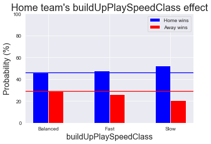

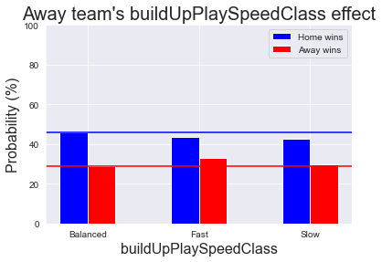

```python
team_attribute_str('buildUpPlaySpeedClass')
```

Home team's Slow class slightly increases the home winning probability while other classes have no major effect. In contrary, away team's Fast class slighlty increases the away winning probability while other classes have no major effect.

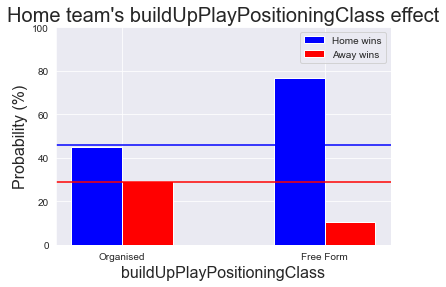

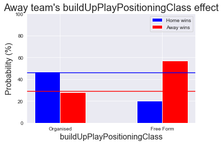

```python
team_attribute_str('buildUpPlayPositioningClass')
```

This attribute is very important in this game, and it's proven from the graphs. Home teams with free form positioning have more home winning probabilities than normal as it reaches **about 77%**. The same holds true for away teams with free form positioning as the away winning probabilities increaes to **about 58%** which is more than home winning prior probability. Amazing!

All other string attributes can be analyzed the same way. **Please, feel free to change the attribute value in the next cell, then run it.**

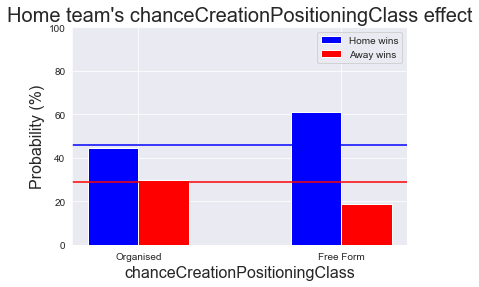

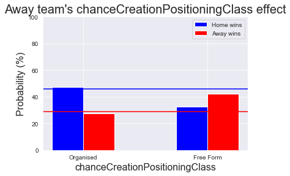

```python
# Change the value of this variable with appropriate attribute name then run the cell
team_attribute_str('chanceCreationPositioningClass')
```

### 7. Which players have improved the most?

```python
df_team['team_name'] = df_team['team_long_name']
```

```python
def improvement(attribute='overall_rating', table_type='player', start_year=2008, end_year=2016):
    '''
    Arguments:
     attribute is the name of the requried attribute from the attributes table as string
     table_type it's wether the player table or the team table as string
     start_year as integer
     end_year as integer
    Usage: associates the attribute's values to the player names on the start and end years, then calculates the
     perecentage imporvment throghout these years
    Output: a graph showing the most ten player/ team imporvements
    '''
    # Check if table_type is entered correctly
    if table_type == 'player':
        df = df_player_attributes
    elif table_type == 'team':
        df = df_team_attributes
    else:
        print('Sorry, there is no table named {}.'.format(table_type))
        return
    # Check if the entered attribute is in the attributes table
    if attribute not in df.columns:
        print('Sorry, this attribute is not in the {} attributes table!'.format(table_type))
        return
    # Check if the entered attribute has numerical values
    elif not pd.api.types.is_numeric_dtype(df[attribute]):
        print('Sorry, this attribute has no numerical values!')
        return
    # Check if the enterd years are integers
    if not (isinstance(start_year, int) and isinstance(end_year, int) and end_year >= start_year):
        print('Sorry, the entered years are not correct!')
        return
    # Extract year from date
    df['start_year'] = df['date'].dt.year.astype(int)
    df['end_year'] = df['date'].dt.year.astype(int)
    # Filter data based on entered values
    df_start = df[df['start_year']==start_year]
    df_end = df[df['end_year']==end_year]
    # Remove duplicates if any by keeping the outer most values
    df_start = df_start.drop_duplicates(['{}_api_id'.format(table_type), 'start_year'], 'first').set_index('{}_api_id'.format(table_type))
    df_start['{}_start'.format(attribute)] = df_start[attribute]
    df_end = df_end.drop_duplicates(['{}_api_id'.format(table_type), 'end_year'], 'last').set_index('{}_api_id'.format(table_type))
    df_end['{}_end'.format(attribute)] = df_end[attribute]
    # Add start and end values of attributes to the specified table
    df_attribute = pd.concat([eval('df_{}'.format(table_type)).set_index('{}_api_id'.format(table_type)),
                    df_start['{}_start'.format(attribute)],
                    df_end['{}_end'.format(attribute)]], axis=1)
    # Drop nan after concatination
    df_attribute.dropna(inplace=True)
    # Check if the dataframe is not empty
    if df_attribute.empty:
        print('Sorry, no data to analysis from {} to {}!'.format(start_year, end_year))
        return
    # Calculate percentage of improvement
    df_attribute['improvement'] = (df_attribute['{}_end'.format(attribute)]
                                  - df_attribute['{}_start'.format(attribute)]) / df_attribute['{}_start'.format(attribute)] * 100

    # Plot the graph
    df_attribute.set_index('{}_name'.format(table_type))['improvement'].nlargest(10).plot(kind='bar')
    plt.suptitle('Imporvement in {} from {} to {}'.format(attribute, start_year, end_year), fontsize=20)
    plt.xlabel('{}'.format(table_type.capitalize()), fontsize=16)
    plt.ylabel('Percentage', fontsize=16);
```

Let's start by the default values by getting the most imporved players based on their overall rating from the start of the database to its end.

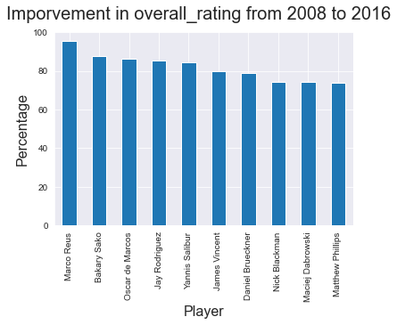

```python
improvement()
```

It shows that Marco Reus is the most imporved player throughout this period with **about 95%** overall improvement!

Next, let's take the last year of the database.

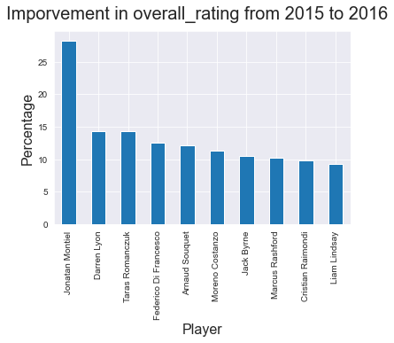

```python
improvement(start_year=2015)
```

The improvement throughout one year is small, so the most imporved player from year 2015 to year 2016 is Jonatan Montiel with **about 27%** overall improvement while the following player never reached 15% overall improvement!

Also, let's discover which goal keepers haver imporved the most within the 5 years from 2010 to 2014.

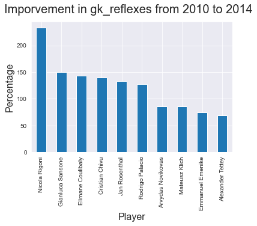

```python
improvement('gk_reflexes', 'player', 2010, 2014)
```

With **more than 200%** improvement, the most improved goal keeper is Nicola Rigoni based on goal keeping reflexes from year 2010 to year 2014

Finally, we can analyze each attribute separately like reactions skills. **Please, feel free to change the values in the next cell, then run it.**

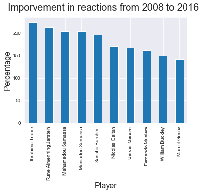

```python
# Change the values of this function then run the cell
improvement('reactions', 'player', 2008, 2016)
```

### 8. Which teams have improved the most?

The previous function can be used by passing 'team' to table_type parameter. Again, we can't get overall team improvement like we did with the players because there is no attribute with such value in the team attributes table. And we can't get the average between the given skills because it needs to be weighted average based on the sensitivity of each attribute on the overall team performance. So, each attibute will be analyzed separately.

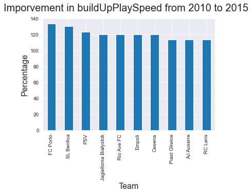

```python
improvement('buildUpPlaySpeed', 'team', 2010, 2015)
```

Between the years 2010 and 2015, the most improved team in build up play speed is FC Porto with **more than 130%** improvement followed by SL Benfica with close value then PSV.

Finally, check the most teams with improvement in defence.

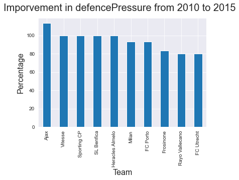

```python
improvement('defencePressure', 'team', 2010, 2015)
```

Between the same years from 2010 to 2015, the most imporved team in defence pressure is Ajax with **more than 110%** improvement.

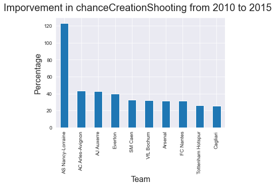

```python
# Change the values of this function then run the cell
improvement('chanceCreationShooting', 'team', 2010, 2015)
```

## Conclusions

- Interesting facts:
  1. Netherlands got the league with most scored goals.
  2. Spain is the leading country in home winning percentage with FC Barcelona and Real Madrid CF in the lead in that over europe teams.
  3. Scoltland is the leading country in away winning percentage with Rangers in the lead in that over europe teams.
  4. Real Madrid CF and FC Barcelona are the leading teams in most scored home goals.
  5. FC Barcelona got the lead in home goals difference and away goals difference.
  6. Marco Reus is the most imporved player throughout the period between 2008 and 2016 with about 95% overall improvement.
  7. Nicola Rigoni is the most improved goal keeper based on goal keeping reflexes throughout the period between 2010 and 2014.
  8. FC Porto is the most improved team in build up play speed throughout the period between 2010 and 2015.
  9. Ajax is the most imporved team in defence pressure throughout the period between 2010 and 2015.
- Factors that might affect the match result:
  1. Prior Home win, Away win, Draw probabilities equal 45.8%, 28.8%, and 25.4%, respectively.
  2. Home and away strategy affects the match result in a minor way. This conclusion is questionable because it is not logical. This might have occured due to averaging the values of the positions of the eleven players. For upcoming analysis, it's better to consider it as different strategies, then be analyzed using classes instead of numerical values.
  3. The player's average age barely affect the prior probabilities.
  4. The less the values of home players' overall rating the less the probability of home winning, and the more the values of home players' overall rating the more the probability of home winning. It reached 80%! at the last category.
  5. The less the values of away players' overall rating the less the probability of away winning, and the more the values of away players' overall rating the more the probability of away winning. It reached about 59%! at the last category (more than prior probability of home winning).
  6. The home winning probability reaches more than 80%! when home players' reactions are between 80 and 85, and the away winning probability reaches more than 60%! when away player's reactions are between 80 and 85.
  7. When the home players' attacking work rate is high, there is more chance of home winning. The same result holds true for the away players.
  8. As the home team's defence pressure increases more than the average, the home winning probability increases as it reached more than 60% at the last category. The away winning probability reached about 46% at the last category. This posterior probability is greater than the posterior proability of home winning.
  9. Home teams with free form positioning have more home winning probabilities as it reached about 77%. The same holds true for away teams with free form positioning as the away winning probabilities increaed to about 58% (more than home winning prior probability).

Note that: All these factors are analyzed separatley based on Bayes' Theroem which means that other factors are fixed at their average values during the analysis. This might be not practical, but it can be considered as preliminary analysis. Also, there are no conclusions about signifcance here, as it needs inferential statistical analysis which is not used in this report.